# Assignment 5 - RBF SVM

# Visualizing Performance

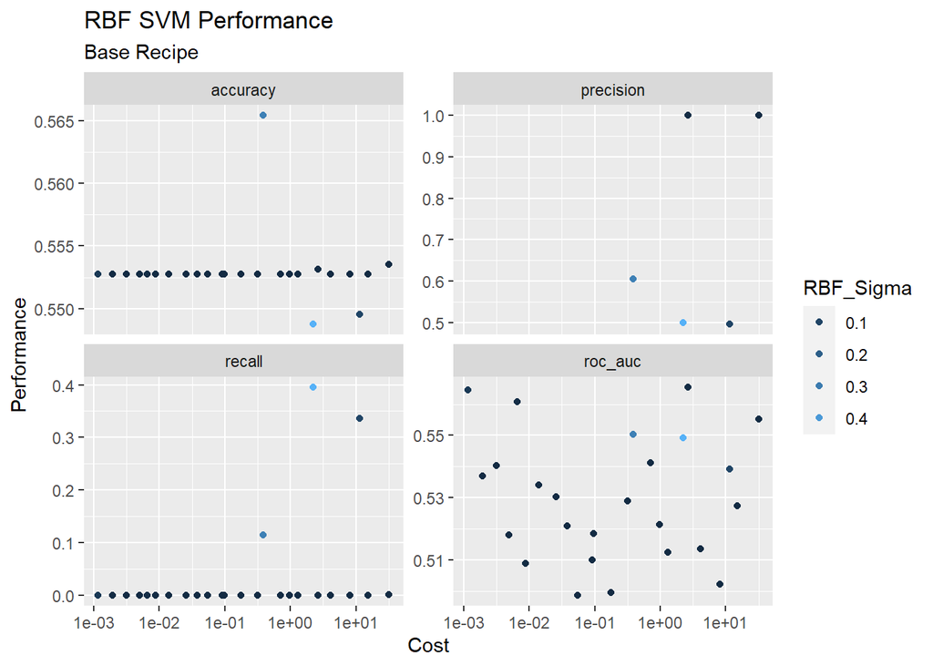

```r
rbfsvm_base_tune%>%
collect_metrics()%>%
ggplot(aes(x = cost, y = mean,color=rbf_sigma)) +
  geom_point() +
  scale_x_log10()  +
  facet_wrap(~.metric, scales = "free_y") +
  guides(colour = guide_legend(title = 'RBF_Sigma')) +
  labs(title = "RBF SVM Performance",
       subtitle = "Base Recipe",
       x = "Cost", y = "Performance")
```

Using `show_best` to view model performance based on optimization metric

```r
rbfsvm_base_tune %>%
  show_best(metric = "roc_auc") %>%
  kable(digits = 3)
```

| cost | rbf_sigma | .metric | .estimator | mean | n | std_err | .config |
| --- | --- | --- | --- | --- | --- | --- | --- |
| 2.652 | 0.004 | roc_auc | binary | 0.566 | 30 | 0.011 | Preprocessor1_Model02 |
| 0.001 | 0.055 | roc_auc | binary | 0.565 | 30 | 0.010 | Preprocessor1_Model16 |
| 0.007 | 0.010 | roc_auc | binary | 0.561 | 30 | 0.010 | Preprocessor1_Model04 |
| 31.601 | 0.001 | roc_auc | binary | 0.555 | 30 | 0.013 | Preprocessor1_Model23 |
| 0.387 | 0.316 | roc_auc | binary | 0.550 | 30 | 0.008 | Preprocessor1_Model17 |

Using `select_best` to isolate the best model

```r
rbfsvm_base_tune %>%
  select_best(metric = "roc_auc")%>%
  kable(digits = 3)
```

| cost | rbf_sigma | .config |
| --- | --- | --- |
| 2.652 | 0.004 | Preprocessor1_Model02 |

Pulling all metrics for the best model

```r
rbfsvm_base_metric%>%
  subset(.config == 'Preprocessor1_Model02')%>%
  kable(digits = 3)
```

| cost | rbf_sigma | .metric | .estimator | mean | n | std_err | .config |
| --- | --- | --- | --- | --- | --- | --- | --- |
| 2.652 | 0.004 | accuracy | binary | 0.553 | 30 | 0.001 | Preprocessor1_Model02 |
| 2.652 | 0.004 | precision | binary | 1.000 | 1 | NA | Preprocessor1_Model02 |
| 2.652 | 0.004 | recall | binary | 0.001 | 30 | 0.001 | Preprocessor1_Model02 |
| 2.652 | 0.004 | roc_auc | binary | 0.566 | 30 | 0.011 | Preprocessor1_Model02 |

Same process as mentioned above for base recipe was applied to the Enhanced Recipe

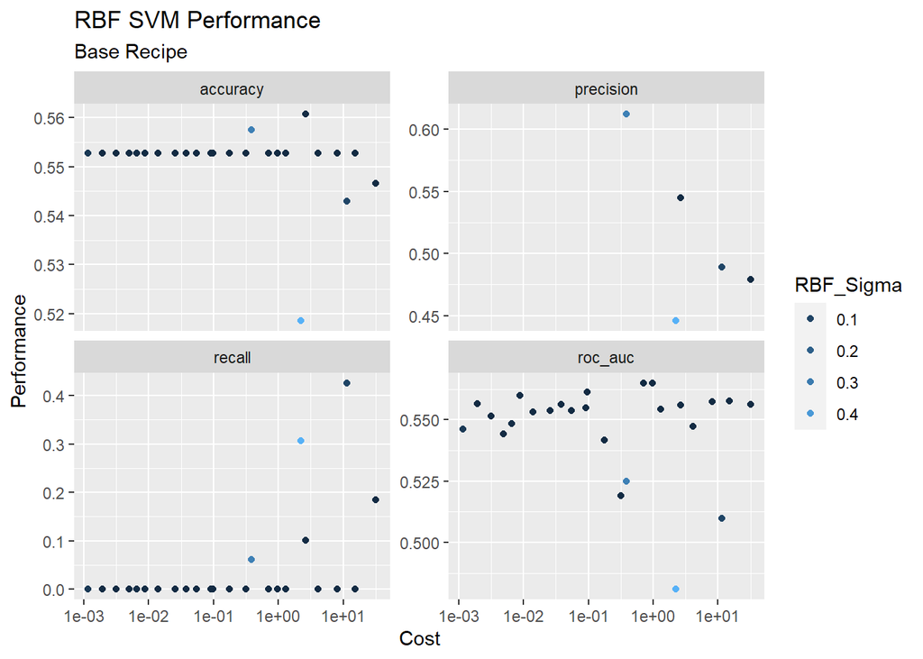

```r
rbfsvm_enhanced_tune%>%
collect_metrics()%>%
ggplot(aes(x = cost, y = mean,color=rbf_sigma)) +
  geom_point() +
  scale_x_log10()  +
  facet_wrap(~.metric, scales = "free_y") +
  guides(colour = guide_legend(title = 'RBF_Sigma')) +
  labs(title = "RBF SVM Performance",
       subtitle = "Base Recipe",
       x = "Cost", y = "Performance")
```

```r
rbfsvm_enhanced_tune %>%
  show_best(metric = "roc_auc") %>%
  kable(digits = 3)
```

| cost | rbf_sigma | .metric | .estimator | mean | n | std_err | .config |
| --- | --- | --- | --- | --- | --- | --- | --- |
| 0.974 | 0.000 | roc_auc | binary | 0.565 | 30 | 0.011 | Preprocessor1_Model05 |
| 0.704 | 0.000 | roc_auc | binary | 0.565 | 30 | 0.011 | Preprocessor1_Model14 |
| 0.097 | 0.000 | roc_auc | binary | 0.561 | 30 | 0.011 | Preprocessor1_Model07 |
| 0.009 | 0.002 | roc_auc | binary | 0.560 | 30 | 0.010 | Preprocessor1_Model12 |
| 15.127 | 0.000 | roc_auc | binary | 0.558 | 30 | 0.011 | Preprocessor1_Model25 |

```r
rbfsvm_enhanced_tune %>%
  select_best(metric = "roc_auc")%>%
  kable(digits = 3)
```

| cost | rbf_sigma | .config |
| --- | --- | --- |
| 0.974 | 0 | Preprocessor1_Model05 |

```r
rbfsvm_enhanced_metric%>%
  subset(.config == 'Preprocessor1_Model05')%>%
  kable(digits = 3)
```

| cost | rbf_sigma | .metric | .estimator | mean | n | std_err | .config |
| --- | --- | --- | --- | --- | --- | --- | --- |
| 0.974 | 0 | accuracy | binary | 0.553 | 30 | 0.000 | Preprocessor1_Model05 |
| 0.974 | 0 | precision | binary | NaN | 0 | NA | Preprocessor1_Model05 |
| 0.974 | 0 | recall | binary | 0.000 | 30 | 0.000 | Preprocessor1_Model05 |
| 0.974 | 0 | roc_auc | binary | 0.565 | 30 | 0.011 | Preprocessor1_Model05 |

# Findings

Based on optimization metrics 0.566 (Base Recipe) vs 0.565 (Enhanced Recipe), the base recipe shows a better performance. For illustrative purpose feature importance of both recipe is shown below. Insights will be discussed more in Summary Report

# Feature Importance

[figure not shown]

```r
best_base_model<-
    svm_rbf(cost = 2.652,
            rbf_sigma = 0.004) %>%
    set_mode(('classification')) %>%
    set_engine('kernlab',importance = "impurity")

best_base_wf<-
  rbfsvm_base_wf%>%
  update_model(best_base_model)

best_base_fit<-
  best_base_wf%>%
  last_fit(data_split)

prepped_base_recipe <- prep(rbfsvm_base_recipe)
baked_base_data <- bake(prepped_base_recipe, new_data = data_train)

extracted_base_fit <- extract_fit_parsnip(best_base_fit)

vip(
      object = extracted_base_fit,
      method = "permute",
      target = "Up_Down",
      reference_class = "Up",
      train = baked_base_data,
      metric = "auc",
      pred_wrapper = kernlab::predict,
      nsim = 5)
```

```r
best_enhanced_model<-
    svm_rbf(cost = 0.974,
          rbf_sigma = 0) %>%
    set_mode(('classification')) %>%
    set_engine('kernlab',importance = "impurity")

best_enhanced_wf<-
  rbfsvm_enhanced_wf%>%
  update_model(best_enhanced_model)

best_enhanced_fit<-
  best_enhanced_wf%>%
  last_fit(data_split)
```

```
## ! train/test split: preprocessor 1/1, model 1/1 (predictions): some 'x' values beyond bounda...
```

[figure not shown]

```r
prepped_enhanced_recipe <- prep(rbfsvm_enhanced_recipe)
baked_enhanced_data <- bake(prepped_enhanced_recipe, new_data = data_train)

extracted_enhanced_fit <- extract_fit_parsnip(best_enhanced_fit)

vip(
      object = extracted_enhanced_fit,
      method = "permute",
      target = "Up_Down",
      reference_class = "Up",
      train = baked_enhanced_data,
      metric = "auc",
      pred_wrapper = kernlab::predict,
      nsim = 5)
```

# Confusion Matrix

```r
best_rbfsvm_base_model<-select_best(rbfsvm_base_tune)
rbfsvm_base_tune%>%conf_mat_resampled(parameters = best_rbfsvm_base_model)
```

```
## # A tibble: 4 × 3
##   Prediction Truth    Freq
##   <fct>      <fct>   <dbl>
## 1 Down       Down    0.333
## 2 Down       Up      0
## 3 Up         Down  411.
## 4 Up         Up    508
```

```r
best_rbfsvm_enhanced_model<-select_best(rbfsvm_enhanced_tune)
rbfsvm_enhanced_tune%>%conf_mat_resampled(parameters = best_rbfsvm_enhanced_model)
```

```
## # A tibble: 4 × 3
##   Prediction Truth  Freq
##   <fct>      <fct> <dbl>
## 1 Down       Down      0
## 2 Down       Up        0
## 3 Up         Down    411
## 4 Up         Up      508
```

# Saving Results

Base recipe was the strongest performing model based on the optimization metric (ROC_AUC) so the details relating to it were saved.

```r
save(rbfsvm_base_metric, best_base_wf, best_base_model,
     file = 'rbfsvm_base_objects.Rda')
```